# Final Project

Author

Gabe Riedel, Oliver Whitmarsh

Propose a Bayesian model - Oliver Discuss choice of likelihood and assumptions of your model - Oliver Discuss choice of prior, including some prior predictive tuning - Oliver Fit the model to the data - Oliver Perform and summarize posterior inference - Gabe Perform and summarize posterior prediction - Gabe Perform and summarize posterior predictive checking or model comparison - Gabe Perform sensitivity analysis (e.g., how does the posterior change if the prior changes) - Gabe Compare your results with a comparable frequentist analysis - Oliver Report conclusions in the context of the research question - Gabe

```r
library(tidyverse)
library(brms)
```

## Data

```r
library(readr)
library(tidyverse)
cp_data <- read_csv("data/cp_bip.csv")
```

```r
cp_clean <- cp_data |>
  drop_na()
```

Our data come from the Cal Poly baseball team. They are every pitch thrown in the 2025 season by Cal Poly baseball pitchers. These data are recorded with a high speed radar system called Trackman that is present in majority of the college baseball stadiums in the country. Trackman produces CSVs at the end of each game where each row represents a pitch thrown and contains information on the ball flight of the pitch as well as the result of the play. Trackman is a highly accurate radar system designed for high speed ball tracking. Our data are a concatenation of the CSVs from each game in Cal Poly’s 2025 season.

Predict Hit from ExitSpeed, Angle, and Direction

```r
cp_clean <- cp_clean |>
  mutate(
    ExitSpeed_c = ExitSpeed - mean(ExitSpeed, na.rm = TRUE),
    Angle_c = Angle - mean(Angle, na.rm = TRUE),
    Direction_c = Direction - mean(Direction, na.rm = TRUE)
  )
```

## Propose a Bayesian model

We propose a Bayesian logistic regression model to estimate the probability that a batted ball results in a hit, using three quantitative predictors: ExitSpeed, LaunchAngle, and Direction. The outcome variable, Hit, is binary (1 = hit, 0 = no hit). Because all three predictors are quantitative and have been centered, the intercept in the model reflects the log-odds of a hit given the averages: exit speed, Angle, and Direction.

The logistic model is: logit(P(Hit = 1)) = B_0 + B_1 * ExitSpeed_c + B_2* Angle_c + B_3 * Direction_c

## Discuss choice of likelihood and assumptions of your model

We use a Bernoulli likelihood in our Bayesian logistic regression model because our response variable, Hit, is binary (1 = hit, 0 = no hit). The likelihood assumes that each observation (each batted ball) has its own chance of being a hit, and that chance is modeled using our predictors — Exit Speed, Launch Angle, and Direction — through a logit (logistic) link.

To determine priors for our parameters, we based our estimates on Gabe’s knowledge of baseball. We are setting priors for four parameters: B_0, B_1, B_2, and B_3. Starting with the intercept, B_0, we considered the baseline probability of getting a hit when all predictors are at their average values (since we centered them). Based on Gabe’s experience, this probability is around 30%. Converting that to log-odds gives log(0.3 / 0.7) ≈ -0.847. Since we’re not very confident in this estimate, we allow for more flexibility by placing a prior of B_0 ~ N(-0.847, 1.5).

Next, we set a prior for the Exit Speed coefficient. Because we believe that higher exit velocity almost always increases the chance of a hit, we place the prior on positive values. For instance, if a 1 mph increase improves the log-odds of a hit by roughly 0.05, then a prior of B_ExitSpeed_c ~ N(0.05, 0.025) seems reasonable.

Although the relationship between launch angle and the chance of a hit is complex, there is some evidence that moderately increasing launch angle can improve hitting outcomes (e.g., line drives). To reflect this, we place a prior of B_Angle_c ~ N(0.1, 0.2), suggesting a modest expected positive effect, while still allowing for substantial uncertainty in either direction.

Lastly, placing a prior on direction is more challenging, since the relationship between direction and the probability of a hit is not clearly positive or negative. Because of this uncertainty, we assign a prior of B_Direction_c ~ N(0, 0.2), reflecting our belief that the effect is likely small but allowing for a wide range of plausible values.

```r
library(brms)

priors <- c(
  prior(normal(-0.847, 1.5), class = "Intercept"),
  prior(normal(0.05, 0.025), class = "b", coef = "ExitSpeed_c"),
  prior(normal(0.1, 0.2), class = "b", coef = "Angle_c"),
  prior(normal(0, 0.2), class = "b", coef = "Direction_c")
)

fit_prior_only <- brm(
  Hit ~ ExitSpeed_c + Angle_c + Direction_c,
  data = cp_clean,
  family = bernoulli(link = "logit"),
  prior = priors,
  sample_prior = "only",
  chains = 4,
  cores = 4,
  iter = 2000,
  seed = 123
)
```

[output not shown]

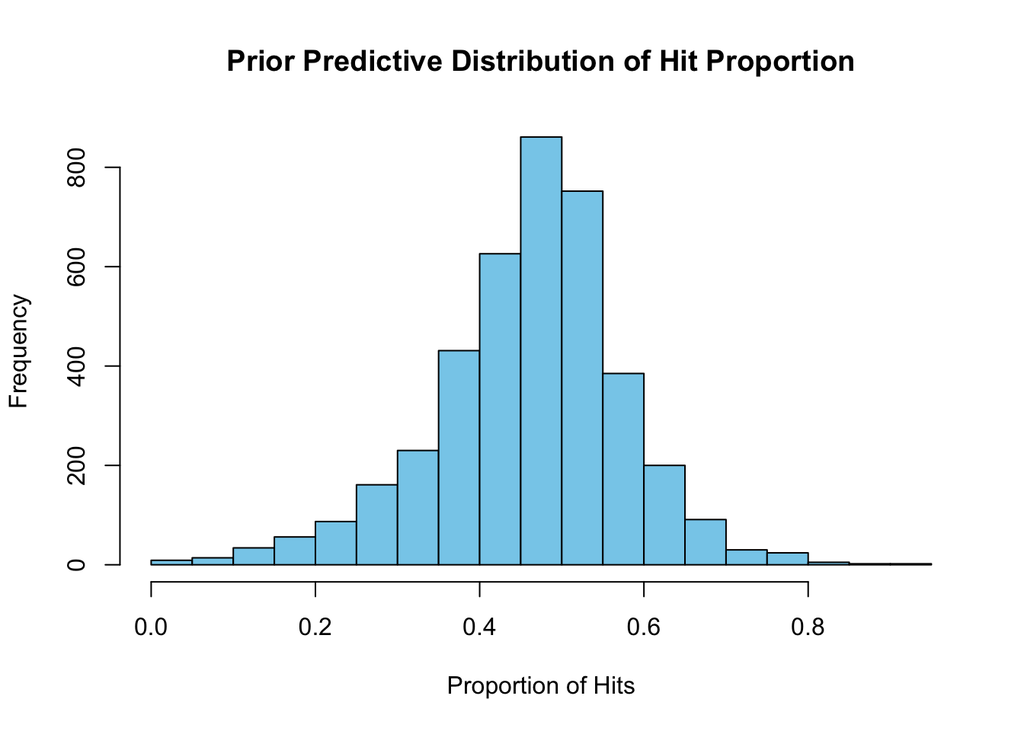

```r
# Simulate predicted hits from the prior
prior_predictions <- posterior_predict(fit_prior_only)

# Calculate the proportion of hits for each simulated dataset
prior_hit_props <- rowMeans(prior_predictions)

# Plot distribution of prior predictive hit proportions
hist(prior_hit_props,
     main = "Prior Predictive Distribution of Hit Proportion",
     xlab = "Proportion of Hits",
     col = "skyblue",
     breaks = 30)
```

```r
priors <- c(
  prior(normal(-2.847, 1.5), class = "Intercept"), # decrease mean of intercept by 2
  prior(normal(0.05, 0.025), class = "b", coef = "ExitSpeed_c"),
  prior(normal(0.05, 0.2), class = "b", coef = "Angle_c"),
  prior(normal(0, 0.2), class = "b", coef = "Direction_c")
)

fit_prior_only <- brm(
  Hit ~ ExitSpeed_c + Angle_c + Direction_c,
  data = cp_clean,
  family = bernoulli(link = "logit"),
  prior = priors,
  sample_prior = "only",
  chains = 4,
  cores = 4,
  iter = 2000,
  seed = 123
)
```

[output not shown]

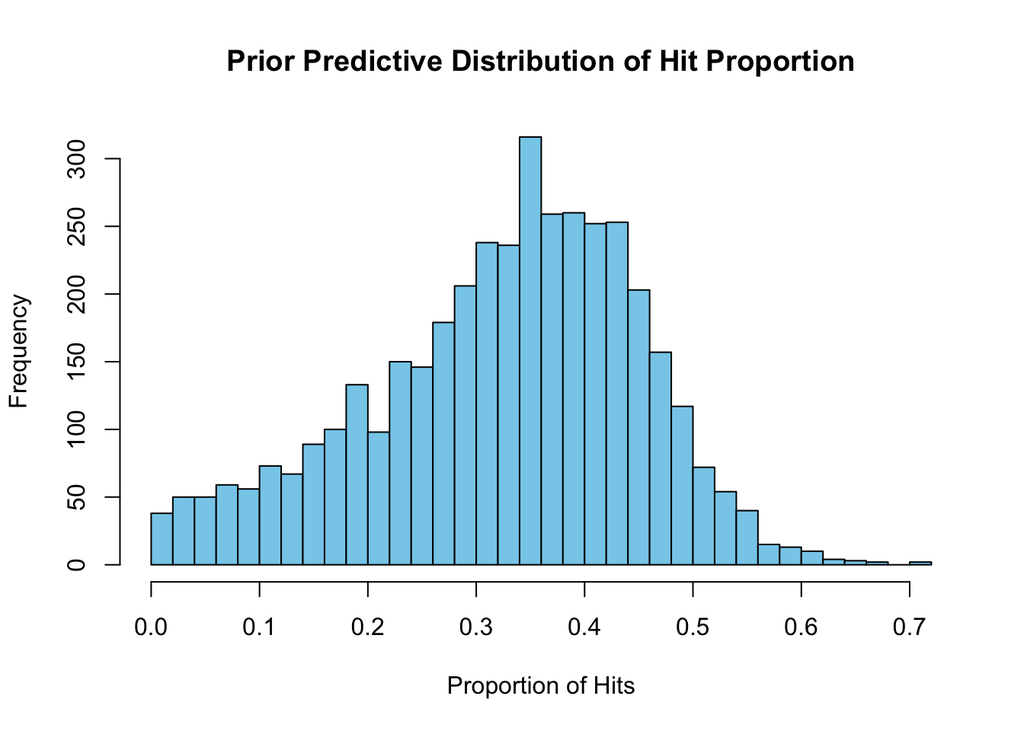

```r
# Simulate predicted hits from the prior
prior_predictions <- posterior_predict(fit_prior_only)

# Calculate the proportion of hits for each simulated dataset
prior_hit_props <- rowMeans(prior_predictions)

# Plot distribution of prior predictive hit proportions
hist(prior_hit_props,
     main = "Prior Predictive Distribution of Hit Proportion",
     xlab = "Proportion of Hits",
     col = "skyblue",
     breaks = 30)
```

Now this distribution of the proportion of hits looks a lot better, thus we have finalized our priors.

## Fit the model to the data

```r
# Define priors
priors <- c(
  prior(normal(-2.847, 1.5), class = "Intercept"),  # Decreased intercept mean
  prior(normal(0.05, 0.025), class = "b", coef = "ExitSpeed_c"),
  prior(normal(0.05, 0.2), class = "b", coef = "Angle_c"),
  prior(normal(0, 0.2), class = "b", coef = "Direction_c")
)

# Fit the Bayesian logistic regression model
fit <- brm(
  Hit ~ ExitSpeed_c + Angle_c + Direction_c,
  data = cp_clean,
  family = bernoulli(link = "logit"),
  prior = priors,
  chains = 4,
  cores = 4,
  iter = 2000,
  seed = 123
)
```

[output not shown]

```r
summary(fit)
```

```
 Family: bernoulli
  Links: mu = logit
Formula: Hit ~ ExitSpeed_c + Angle_c + Direction_c
   Data: cp_clean (Number of observations: 1564)
  Draws: 4 chains, each with iter = 2000; warmup = 1000; thin = 1;
         total post-warmup draws = 4000

Regression Coefficients:
            Estimate Est.Error l-95% CI u-95% CI Rhat Bulk_ESS Tail_ESS
Intercept      -0.53      0.06    -0.64    -0.42 1.00     2355     2639
ExitSpeed_c     0.05      0.00     0.04     0.06 1.00     3430     3066
Angle_c        -0.01      0.00    -0.01    -0.01 1.00     4594     3403
Direction_c    -0.01      0.00    -0.01    -0.00 1.00     5021     3409

Draws were sampled using sampling(NUTS). For each parameter, Bulk_ESS
and Tail_ESS are effective sample size measures, and Rhat is the potential
scale reduction factor on split chains (at convergence, Rhat = 1).
```